# Analiza wakacji w Hiszpanii

Projekt zaliczeniowy z R

Pavlo Melnyk

### Spis treści

1. Wstęp
2. Początek analizy
3. Regresja liniowa i drzewo decyzyjne
4. Analiza *ggplot*
   1. *encircle*
   2. *bubble*
   3. *violin*
   4. *lollipop*
   5. *waffle*
   6. *klastry*
   7. *mapa*
5. Podsumowanie

### **Wstęp**

Zbiór danych wykorzystany w niniejszym projekcie został pobrany przy pomocy skryptu, który z kolei pobrał dane ze strony internetowej Wakacje.pl. Zbiór zawiera 1000 obserwacji o 7-dniowych wycieczkach do Hiszpanii dla 2 osób możliwych do realizacji w terminach od *1 marca 2019* do *30 maja 2019*. Przy ponownym pobraniu ze strony i załadowaniu nowego zbioru danych zawarte w tym projekcie wykresy i wartości będą miały inne znaczenia, czyli opisy do nich już nie będą aktualne. Zbiór danych zawiera informacje o **dacie wyjazdu**, **organizatorze wyjazdu**, **cenie za osobę** w PLN, **ogólnej ocenie wycieczki** (od 1 do 10), **gwiazdkach hotelu** (od 1 do 5), **ogólnej liczbie rezerwacji** każdej z obserwacji itd. Projekt ma na celu przeanalizowanie propozycji 7-dniowych wyjazdów realizowanych przez różne biura podróży oraz wyciągnięcie odpowiednich wniosków z analizy.

#### Poniżej znajduje się kilka pierwszych zmiennych i obserwacji z analizowanego zbioru danych:

```r
knitr::opts_chunk$set(fig.align = "center")
d <- read.csv('C:\\Wszystko\\Studia mgr\\Prezentacja i wizualizacja danych\\Projekt\\projekt_r_pmelnyk\\wyniki.csv', header = TRUE, sep = ',')

library(formattable)
library(magrittr)

formattable(d[,c('organizator', 'cena_za_osobe', 'region', 'hotel_gwiazdki', 'ocena_wycieczki')]) %>% head()
```

| organizator | cena_za_osobe | region | hotel_gwiazdki | ocena_wycieczki |
| --- | --- | --- | --- | --- |
| Rainbow | 3149 | Teneryfa | 4.5 | 8.8 |
| Rainbow | 2399 | Teneryfa | 4.0 | 7.3 |
| Itaka | 2439 | Teneryfa | 4.0 | 7.4 |
| Rainbow | 2435 | Gran Canaria | 3.5 | 8.5 |
| Itaka | 2389 | Costa del Sol | 4.5 | 9.7 |
| Rainbow | 1914 | Fuerteventura | 3.5 | 7.8 |

Dla lepszej czytelności tabeli wykorzystano pakiet `formattable`.

Pełna lista zmiennych modelu to:

```r
colnames(d)[2:13]
```

```
##  [1] "termin_wycieczki"  "wyzywienie"        "organizator"
##  [4] "region"            "miejscowosc"       "ocena_wycieczki"
##  [7] "hotel_nazwa"       "hotel_gwiazdki"    "id_wycieczki"
## [10] "liczba_rezerwacji" "cena_za_osobe"     "data_aktualizacji"
```

### **Wstępna analiza zbioru danych oraz jego głównych składowych**

#### Spis i wykres kołowy firm turystycznych oferujących wycieczki spełniające wspominane wyżej kryteria

```r
par(mfrow = c(1,1))
print(levels(factor(d$organizator)))
```

```
##  [1] "Atur"          "Ecco Holiday"  "Exim Tours"    "Itaka"
##  [5] "Itaka & Gala"  "Neckermann"    "Prima Holiday" "Rainbow"
##  [9] "Regent"        "Wezyr"
```

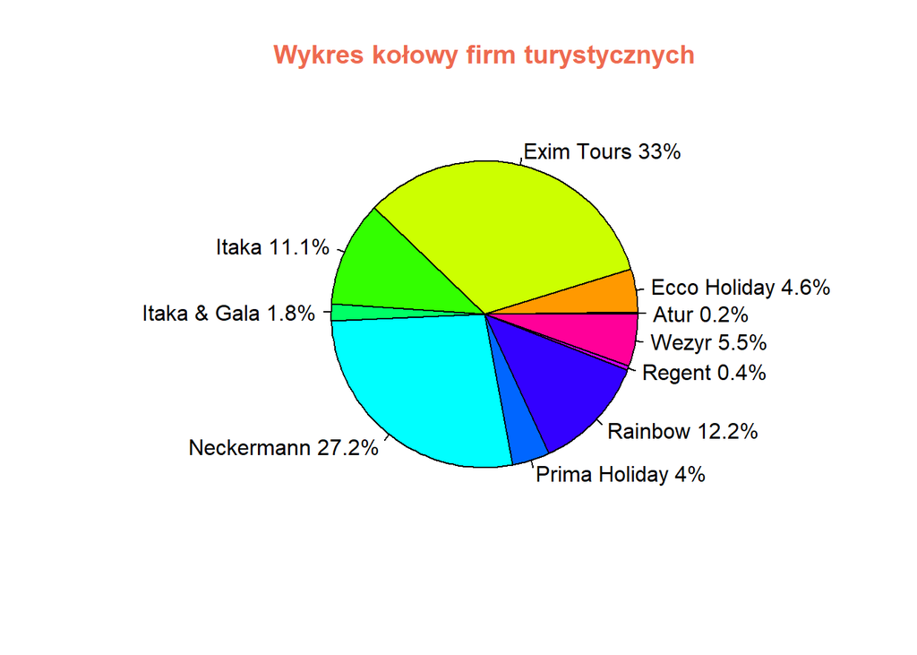

```r
#pie chart organizatorów
slices <- table(d$organizator)
lbls <- levels(factor(d$organizator))
pct <- round(slices/sum(slices)*100, 10)
lbls <- paste(lbls, pct) # add percents to labels
lbls <- paste(lbls,"%",sep="") # ad % to labels
pie(slices,labels = lbls, col=rainbow(length(lbls)),
    main="Wykres kołowy firm turystycznych", col.main = 'coral2')
```

Z wykresu wynika, że w danym segmencie czasowym dominują firmy *Exim Tours* - 33% wszystkich podróży, *Neckermann* - 27,2%, *Rainbow* - 12,2%.

Spójrzmy teraz, jak internauci ocenili wycieczki zorganizowane przez wszystkie firmy.

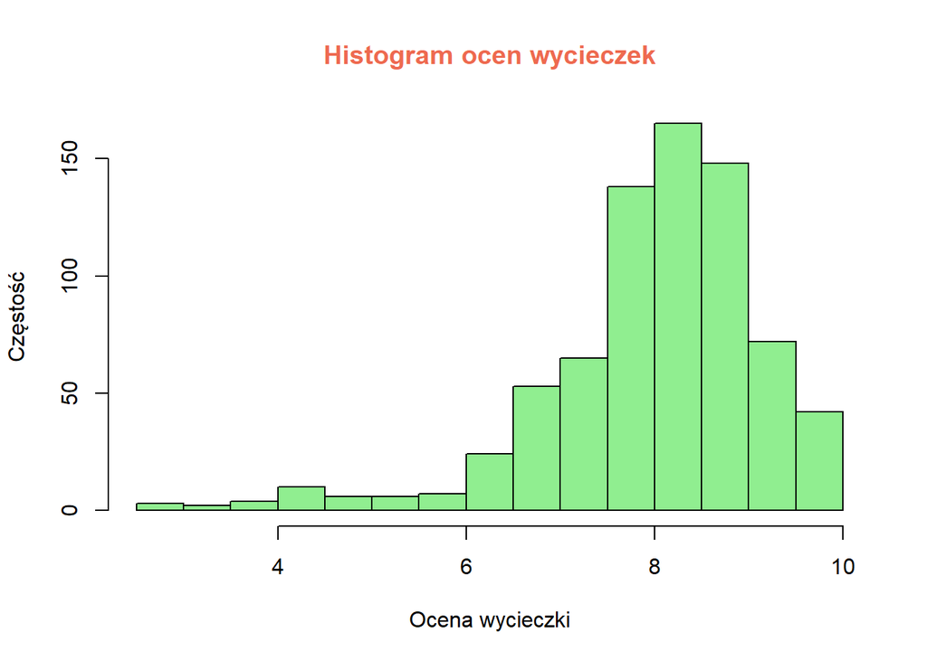

```r
par(mfrow = c(1,1))
hist(d$ocena_wycieczki, col = 'lightgreen', xlab = 'Ocena wycieczki', ylab = 'Częstość', main = 'Histogram ocen wycieczek', col.main = 'coral2')
```

Okazuje się, że w większości oceny były bardziej pozytywne niż negatywne. Rozkład ocen jest zbliżony do normalnego ze średnią 7-8 pkt z 10.

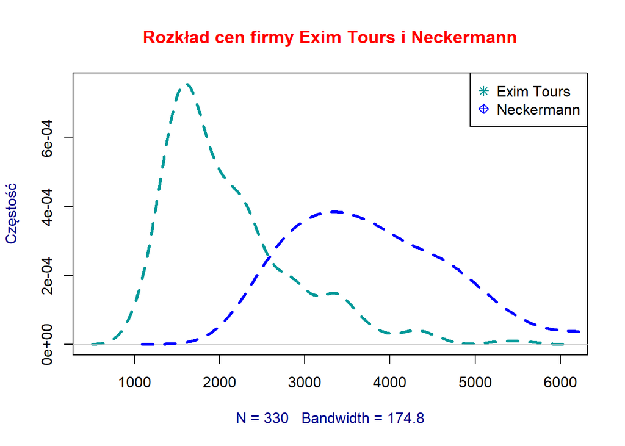

```r
#rozkład cen dwóch największych firm
par(mfrow = c(1,1))
plot(density(d[d$organizator=='Exim Tours',]$cena_za_osobe),main = 'Rozkład cen firmy Exim Tours i Neckermann', col.main = 'red', col = "#009999", lwd = 3, lty = 2, col.lab = 'blue4', ylab = 'Częstość')
lines(density(d[d$organizator=='Neckermann',]$cena_za_osobe), col = "#0000FF", lwd = 3, lty = 2, col.lab = 'blue4')
legend('topright',legend=c("Exim Tours","Neckermann"),
       col=c("#009999","#0000FF"),pch=c(8,9))
```

Z podanych wyżej histogramów można już wywnioskować, że z dwóch najpopularniejszych organizatorów firma *Neckermann* jest o wiele droższa niż firma *Exim Tours*. Ceny wycieczek tej pierwszej w większości przekraczają 3000 zł podczas gdy cen tej drugiej są w większości niższe niż 2000 zł.

Poniżej możemy obserwować rozkłady cen jeszcze czterech firm, których udział procentowy jest mniejszy niż dwóch poprzednich.

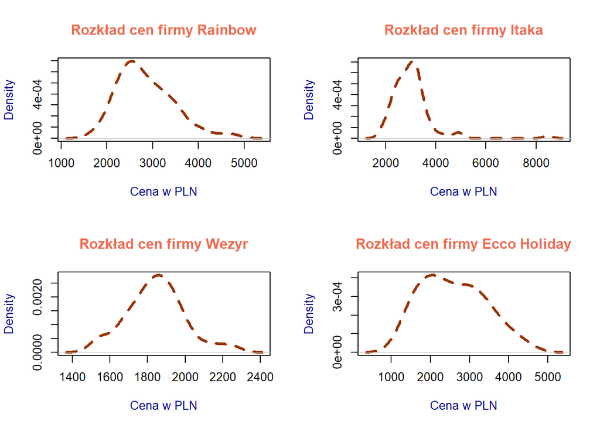

```r
#rozkład cen jeszcze 4 firm
par(mfrow=c(2,2))
pie <- c('Rainbow', 'Itaka', 'Wezyr', 'Ecco Holiday')
#cols <- c("#009999", "#0000FF", "#993300", "#660033")
for (i in pie) {
  plot(density(d[d$organizator==i,]$cena_za_osobe), main = paste("Rozkład cen firmy", i),
       xlab = "Cena w PLN", col.main = 'coral2', col.lab = 'blue4', col = "#993300", lwd = 3, lty = 2)
}
```

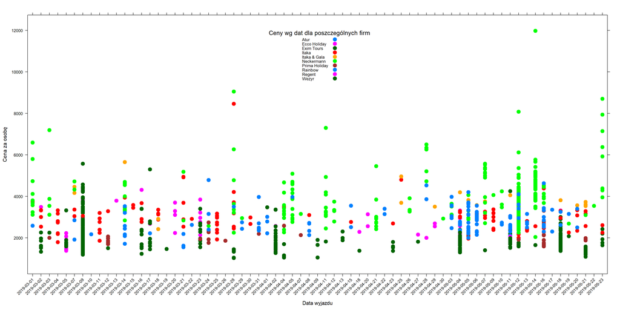

```r
library(lattice)
xyplot(cena_za_osobe ~ termin_wycieczki, d, scales=list(y=list(rot=0), x=list(rot=45,equispaced.log = FALSE)),
       group = organizator, xlab = 'Data wyjazdu', ylab = 'Cena za osobę',
       auto.key = list(title="Ceny wg dat dla poszczególnych firm",
                                            x=0.05,y=0.95, cex=0.8, just = 0.95),
       par.settings = list(superpose.symbol = list(pch = 19, cex = 1.5)), col.lab = 'blue4')
```

A na tym wykresie widzimy (trochę słabo, ale widzimy) ceny dla rożnych terminów wyjazdu. Jak można się domyślić, najwięcej jest ofert z terminem rozpoczęcia przed weekendem, *np. 9 i 28 marca*. Z kolei najmniej wyjazdów rozpoczyna się we wtorki, *np. 19 marca*.

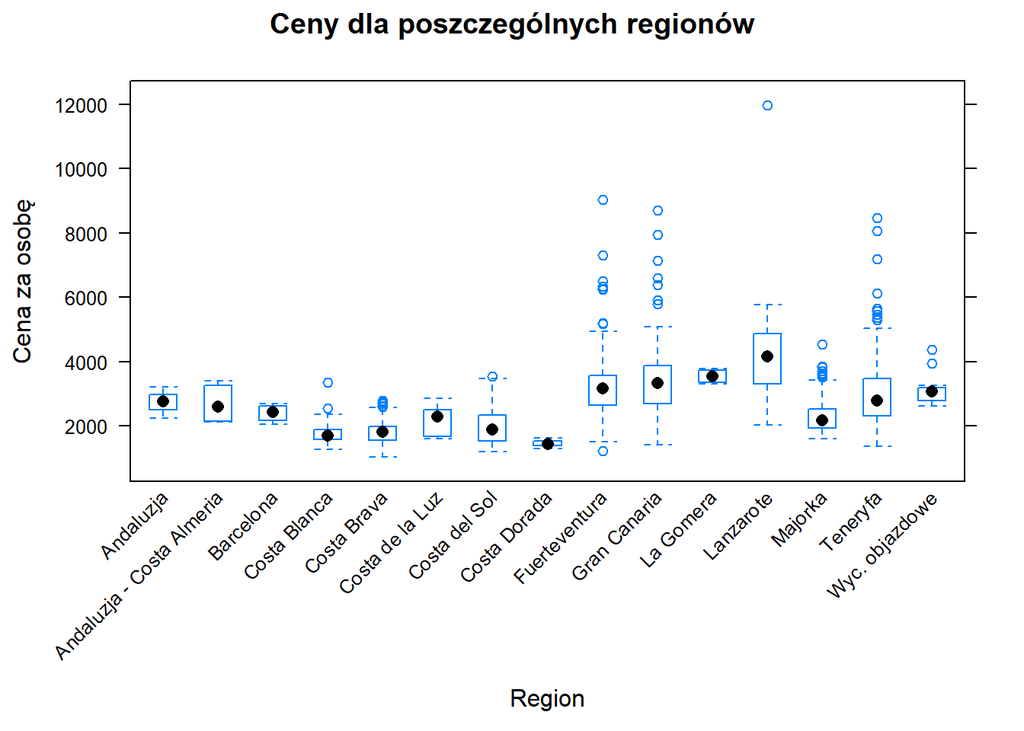

```r
bwplot(d$cena_za_osobe~d$region, scales=list(y=list(rot=0), x=list(rot=45)), col = 'black',
       ylab = 'Cena za osobę', xlab = 'Region', main = "Ceny dla poszczególnych regionów", col.main = 'coral2', col.lab = 'blue4')
```

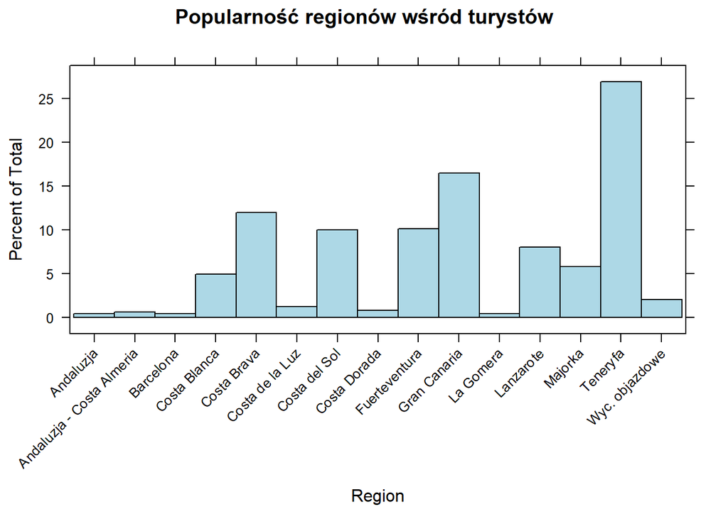

```r
histogram(~d$region, scales=list(y=list(rot=0), x=list(rot=45)), col = 'lightblue',
          xlab = 'Region', main = "Popularność regionów wśród turystów", col.main = 'coral2', col.lab = 'blue4')
```

### **Analiza predykcyjna - regresja i drzewo decyzyjne**

W tej części raportu przeprowadzę analizę modelu regresji liniowej oraz drzewa decyzyjnego zastosowanego do posiadanego zbioru danych. Pierwszy prosty model *m1* będzie wyjaśniać wartości zmiennej *cena_za_osobe* na podstawie zmiennej objaśniającej *ocena_wycieczki*. Drugi model *m2* regresji liniowej będzie zawierać więcej zmiennych. Później *m1* i *m2* można będzie porównać i dowiedzieć się, czy większa liczba zmiennych objaśniających istotnie wpłynęła na jakość modelu.

#### m1

```r
m1<- lm(cena_za_osobe~ocena_wycieczki, data = d)
summary(m1)
```

```
##
## Call:
## lm(formula = cena_za_osobe ~ ocena_wycieczki, data = d)
##
## Residuals:
##     Min      1Q  Median      3Q     Max
## -2154.3  -811.3   -43.8   554.1  6238.1
##
## Coefficients:
##                 Estimate Std. Error t value Pr(>|t|)
## (Intercept)        546.1      267.1   2.044   0.0413 *
## ocena_wycieczki    289.7       32.9   8.806   <2e-16 ***
## ---
## Signif. codes:  0 '***' 0.001 '**' 0.01 '*' 0.05 '.' 0.1 ' ' 1
##
## Residual standard error: 1041 on 743 degrees of freedom
##   (255 observations deleted due to missingness)
## Multiple R-squared:  0.09451,    Adjusted R-squared:  0.09329
## F-statistic: 77.55 on 1 and 743 DF,  p-value: < 2.2e-16
```

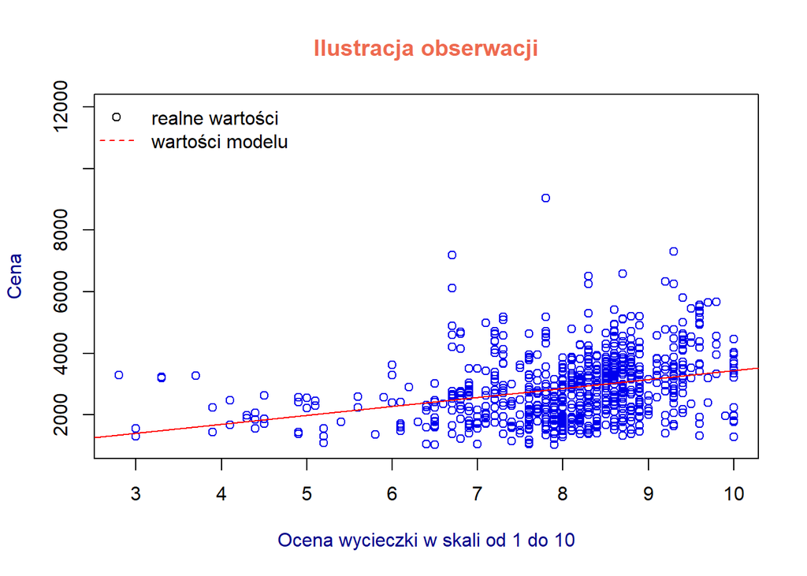

```r
plot(d$cena_za_osobe~d$ocena_wycieczki, xlab="Ocena wycieczki w skali od 1 do 10", ylab="Cena",
     col.main = 'coral2', col = 'blue2', col.lab = 'blue4', main = 'Ilustracja obserwacji')
abline(m1, col='red')
legend("topleft", legend=c("realne wartości","wartości modelu"), col=c("black","red"), pch=c(1,NA), lty=c(NA,2), bty="n")
```

```r
print('Kilka wyestymowanych wartości modelu:')
```

```
## [1] "Kilka wyestymowanych wartości modelu:"
```

```r
m1$fitted.values %>% head()
```

```
##        1        2        3        4        5        6
## 3095.653 2661.064 2690.036 3008.735 3356.406 2805.927
```

Z pierwszego modelu widzimy, że statystyka **R^2** ma bardzo niską wartość - *0,09*, co oznacza, że zmienna *ocena_wycieczki* tylko w 9% wyjaśnia wartość zmiennej *cena_za_osobę*, czyli z tego wynika, że lepsze oceny wycieczek nie zawsze idą w parze z wysokimi cenami. Współczynnik zmiennej *ocena_wycieczki* jest dodatni, wskazuje to na dodatnie nachylenie wyestymowanej prostej.

Zmienna *ocena_wycieczki* jest istotna o wartości *p-value* równej $2*10^{-16}$, czyli istotnie mniejszej od poziomu istotności 0,05. Wartość *p-value* $2,2 * 10^{-16}$ statystyki **F** wskazuje na łączną istotność modelu *m1*. 255 wartości zostało usuniętych z powodu braku danych, ponieważ nie każda wycieczka miała ogólną ocenę podróżników, czyli algorytm zignorował wartości `NA`.

Na wykresie powyżej można zauważyć linię dopasowującą rozproszone wartości cen dla poszczególnych ocen podróży. Zauważalny jest lekki trend wzrostowy, im wyższe zadowolenie z wycieczek, tym więcej za nie trzeba było zapłacić.

Na podstawie wyestymowanych wartości, które leżą na czerwonej linii można przewidywać ceny wycieczek dla innych zbiorów testowych.

Poniżej przeanalizowane są reszty modelu *m1*.

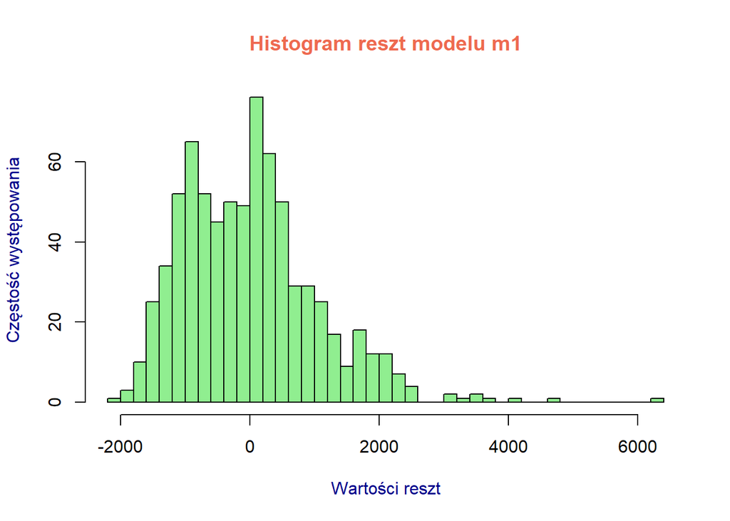

```r
hist(m1$residuals,main = 'Histogram reszt modelu m1', xlab = 'Wartości reszt', ylab = 'Częstość występowania',
     breaks = 50, col.main = 'coral2', col = 'lightgreen', col.lab = 'blue4')
```

```r
shapiro.test(m1$residuals)
```

```
##
##  Shapiro-Wilk normality test
##
## data:  m1$residuals
## W = 0.95134, p-value = 5.799e-15
```

#### m2

```r
set.seed(15686666)
s <- sample.int(nrow(d), floor(0.75*nrow(d)), replace = FALSE)
d.train <- d[s,]
d.test <- d[-s,]
m2 <- lm(cena_za_osobe~ocena_wycieczki+
            hotel_gwiazdki+
            liczba_rezerwacji+
           organizator+
           region, data = d.train)
summary(m2)
```

```
##
## Call:
## lm(formula = cena_za_osobe ~ ocena_wycieczki + hotel_gwiazdki +
##     liczba_rezerwacji + organizator + region, data = d.train)
##
## Residuals:
##      Min       1Q   Median       3Q      Max
## -1891.73  -306.32   -44.86   236.10  2844.13
##
## Coefficients:
##                            Estimate Std. Error t value Pr(>|t|)
## (Intercept)                -5.66844  667.76839  -0.008   0.9932
## ocena_wycieczki            89.18213   37.64665   2.369   0.0185 *
## hotel_gwiazdki            414.28630   69.38095   5.971 6.69e-09 ***
## liczba_rezerwacji           0.02761    0.12519   0.221   0.8256
## organizatorEcco Holiday   429.19284  489.81861   0.876   0.3816
## organizatorExim Tours    -281.53790  476.86459  -0.590   0.5554
## organizatorItaka          -72.72000  484.65095  -0.150   0.8808
## organizatorItaka & Gala   398.05291  628.43289   0.633   0.5270
## organizatorNeckermann     673.54448  482.95412   1.395   0.1642
## organizatorPrima Holiday -323.26805  505.34374  -0.640   0.5229
## organizatorRainbow          3.70762  483.40935   0.008   0.9939
## organizatorWezyr           48.39730  471.95953   0.103   0.9184
## regionCosta Blanca       -557.84114  565.66949  -0.986   0.3249
## regionCosta Brava        -410.01096  412.57798  -0.994   0.3211
## regionCosta de la Luz    -179.93766  490.77156  -0.367   0.7141
## regionCosta del Sol       -70.87191  417.61969  -0.170   0.8654
## regionCosta Dorada       -527.65475  491.66307  -1.073   0.2840
## regionFuerteventura       585.14711  416.51868   1.405   0.1611
## regionGran Canaria        876.48416  413.04302   2.122   0.0347 *
## regionLanzarote          1048.92172  423.49306   2.477   0.0138 *
## regionMajorka             158.18115  422.48767   0.374   0.7084
## regionTeneryfa            420.58122  408.51757   1.030   0.3041
## ---
## Signif. codes:  0 '***' 0.001 '**' 0.01 '*' 0.05 '.' 0.1 ' ' 1
##
## Residual standard error: 552.7 on 298 degrees of freedom
##   (430 observations deleted due to missingness)
## Multiple R-squared:  0.6917, Adjusted R-squared:   0.67
## F-statistic: 31.84 on 21 and 298 DF,  p-value: < 2.2e-16
```

[output not shown]

```
## [1] 573
```

```
## [1] "Liczba wartości NA zmiennej hotel_gwiazdki:"
```

```
## [1] 8
```

W modelu *m2* wyjaśniana jest *cena za osobę*, przy pomocy większej liczby zmiennych. W tym przypadku wartość **R^2** wynosi aż *0,67* - to jest znacząco lepszy wynik niż w modelu m1. Oznacza to, że cenę w tym modelu udało się wyjaśnić aż w 67% przy pomocy zmiennych objaśnianych, a więc większa liczba zmiennych pozytywnie wpływa na efektywność modelu.

Największym poziomem istotności wykazała się zmienna *hotel_gwiazdki*. Współczynnik przy tej zmiennej wynosi *414,3*, co jest zgodne z logiką, bo im więcej gwiazdek ma hotel, tym większa cena za osobę (każda dodatkowa gwiazdka zwiększa cenę za osobę średnio o *414 zł*). *ocena_wycieczki* również jest zmienną istotną o dodatnim współczynniku, tak jak w modelu *m1*. Zmienne *organizator* i *region* algorytm podzielił na odpowiednią ilość zmiennych kategoryzujących. *liczba_rezerwacji* okazała się nieistotna. Jednym z powodów jest obecność dużej ilości wartości `NA` - aż 573!

430 obserwacji zostało usuniętych podczas analizy z powodu braków danych `NA`, w większości zawartych w zmiennej *liczba_rezerwacji*. Statystyka **F** wraz z *p-value* $2,2 * 10^{-16}$ wskazuje na łączną istotność modelu *m2*. Dalej zobaczmy analizę reszt tego modelu.

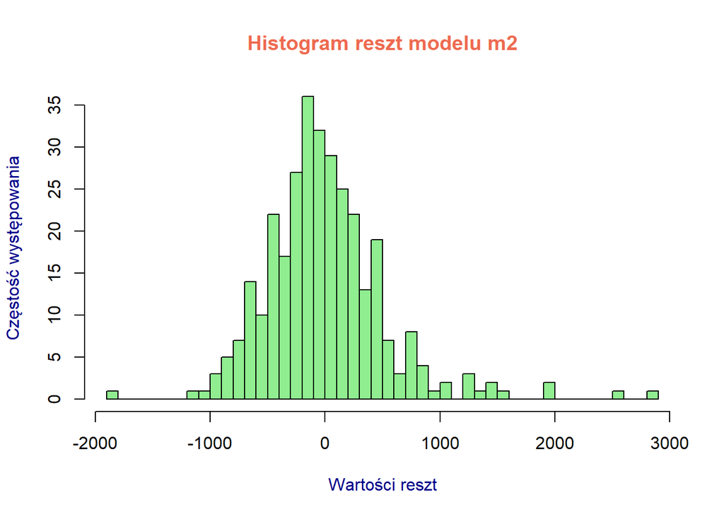

```r
hist(m2$residuals,main = 'Histogram reszt modelu m2', xlab = 'Wartości reszt', ylab = 'Częstość występowania',
     breaks = 50, col.main = 'coral2', col = 'lightgreen', col.lab = 'blue4')
```

```r
shapiro.test(m2$residuals)
```

```
##
##  Shapiro-Wilk normality test
##
## data:  m2$residuals
## W = 0.92299, p-value = 8.935e-12
```

Następnym elementem analizy predykcyjnej będzie drzewo decyzyjne.

#### Drzewo decyzyjne

```r
library(rpart)
library(rpart.plot)
dt <- rpart(cena_za_osobe ~ ocena_wycieczki+hotel_gwiazdki+liczba_rezerwacji+region+organizator+wyzywienie,
            data = d)
par(mfrow = c(1,1))
printcp(dt)
```

```
##
## Regression tree:
## rpart(formula = cena_za_osobe ~ ocena_wycieczki + hotel_gwiazdki +
##     liczba_rezerwacji + region + organizator + wyzywienie, data = d)
##
## Variables actually used in tree construction:
## [1] hotel_gwiazdki  ocena_wycieczki organizator     region
## [5] wyzywienie
##
## Root node error: 1382361930/1000 = 1382362
##
## n= 1000
##
##          CP nsplit rel error  xerror     xstd
## 1  0.355520      0   1.00000 1.00224 0.088974
## 2  0.090628      1   0.64448 0.64597 0.066283
## 3  0.069948      2   0.55385 0.56877 0.064779
## 4  0.039902      3   0.48390 0.50089 0.050753
## 5  0.030186      4   0.44400 0.47162 0.048862
## 6  0.025823      5   0.41382 0.44238 0.048307
## 7  0.025501      6   0.38799 0.43314 0.048252
## 8  0.014845      7   0.36249 0.40264 0.045245
## 9  0.011437      8   0.34765 0.39060 0.047193
## 10 0.010102      9   0.33621 0.37466 0.047340
## 11 0.010000     12   0.30590 0.36732 0.047219
```

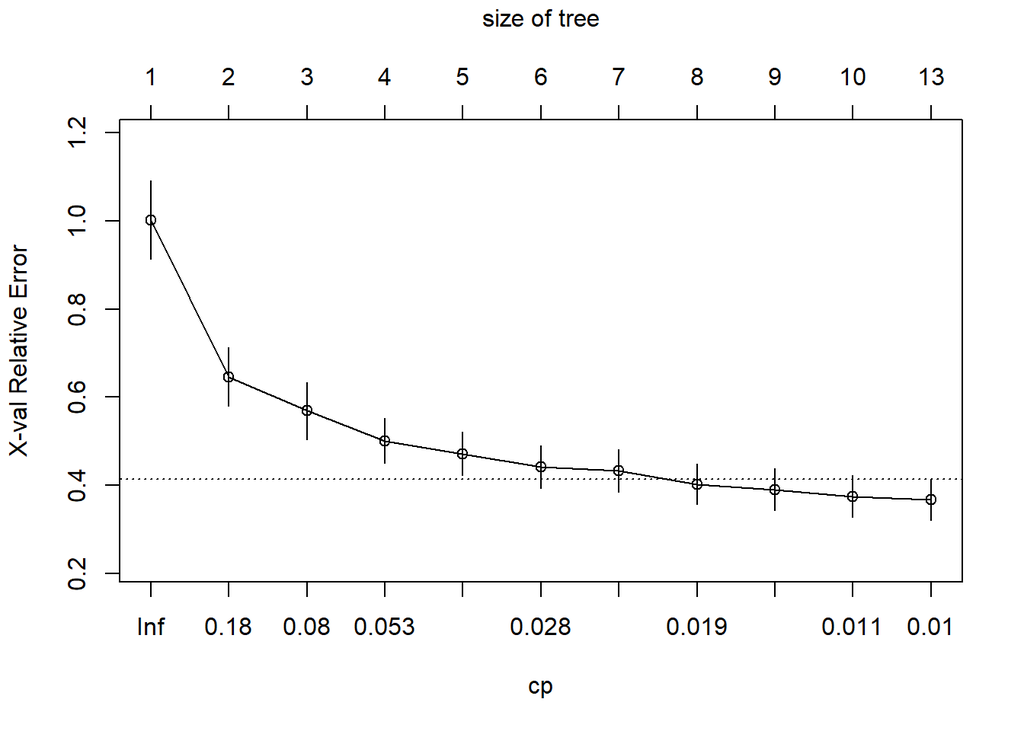

```r
plotcp(dt)
```

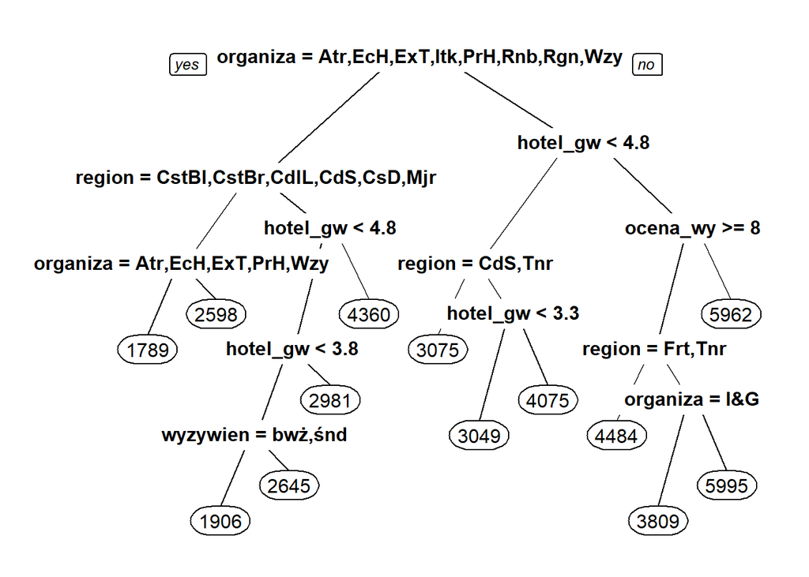

```r
prp(dt)
```

### **Wizualizacja zbioru danych przy pomocy *ggplot***

Na **pierwszym** wykresie widzimy zawarte w czerwonym polu ceny powyżej 6000 zł oraz ocenione wyżej niż na 6 pkt. Wycieczki te oferują 4-5 gwiazdkowe hotele oraz najdroższe destynacje, takie jak *Fuerteventura*, *Gran Canaria* i *Teneryfa*. Wydzielić obszar na czerwono udało się przy pomocy funkcji `encircle` z pakietu `ggalt`. `geom_smooth` narysował krzywą regresji ceny do oceny każdej z wycieczek.

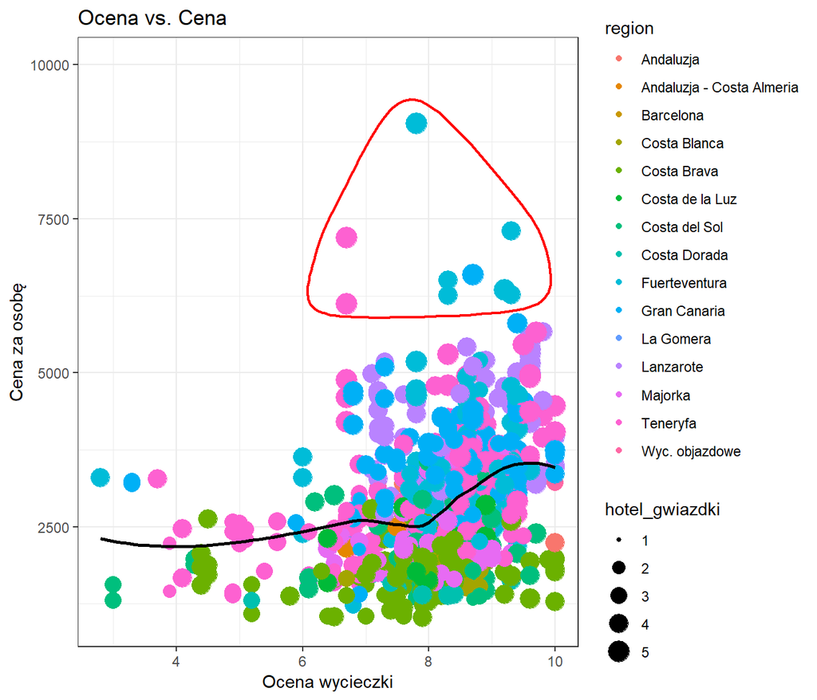

```r
#GGPLOT - zawiera sie w tidyverse
library(tidyverse)
#ENCIRCLE
library(ggalt)
d.select1 <- d[d$cena_za_osobe>6000 & d$ocena_wycieczki > 6,]

theme_set(theme_bw())
ggplot(d, aes(y = cena_za_osobe, x = ocena_wycieczki))+
  geom_point(aes(col = region, size = hotel_gwiazdki), na.rm = TRUE)+
  geom_smooth(method = 'loess', se = F, na.rm = TRUE, col = 'black')+ ylim(c(1000,10000))+
  geom_encircle(aes(y=cena_za_osobe, x=ocena_wycieczki),
                data=d.select1,
                color="red",
                size=2,
                expand=0.05, na.rm = TRUE)+
  labs(y="Cena za osobę",
       x="Ocena wycieczki",
       title="Ocena vs. Cena")+ theme(legend.position = 'right')
```

Na **drugim** wykresie poniżej widzimy rozkład cen dla poszczególnych ocen wycieczek dla trzech wybranych firm wraz z prostymi regresji liniowej dla każdej z nich. Po raz kolejny upewniamy się, że firma *Neckermann* oferuje najdroższe podróże (średnio ponad 3000 zł za osobę) w przeważnie 4-5 gwiazdkowych hotelach, podczas gry *Exim Tours* ma w ofercie tańsze wyjazdy do Hiszpanii w 3-gwiazdkowych i niżej hotelach, jak i również w 4-5 gwiazdkowych. *Itaka* znalazła się w średnim przedziale cenowym. Krzywe regresji wskazują na to, że dla każdej z firm wraz z polepszeniem się ocen wycieczek rośnie ich cena.

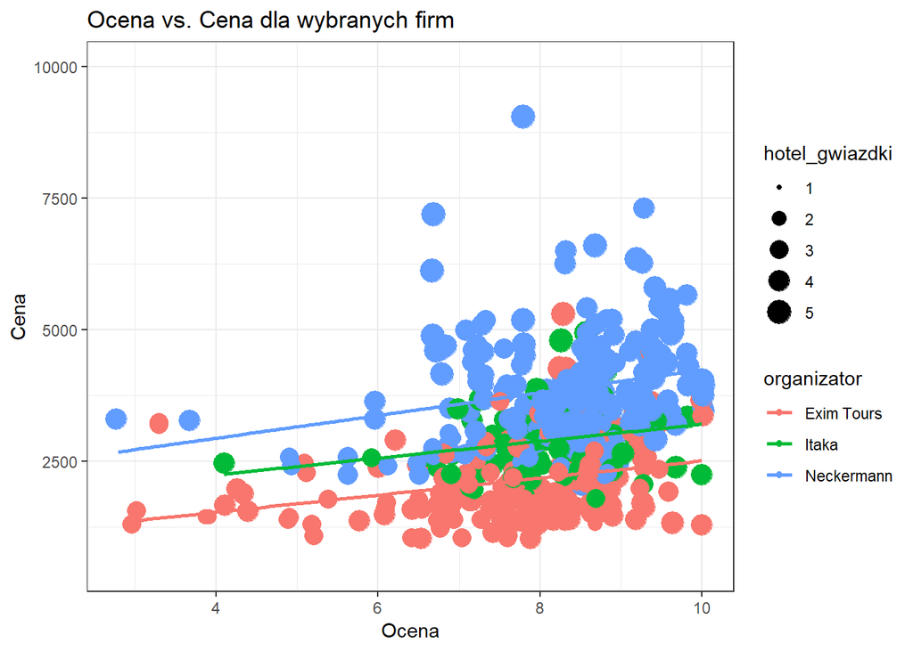

```r
d.select2 <- d[d$organizator %in% c('Exim Tours', 'Neckermann', 'Itaka'),]

theme_set(theme_bw()) #gotowa theme

ggplot(d.select2, aes(y = cena_za_osobe, x = ocena_wycieczki))+
  labs(title = 'Ocena vs. Cena dla wybranych firm', x = 'Ocena', y = 'Cena')+
  geom_jitter(aes(col = organizator, size = hotel_gwiazdki), na.rm = TRUE)+
  geom_smooth(aes(col = organizator), method = 'lm', se = F, na.rm = TRUE)+ylim(c(500,10000))
```

Z **trzeciego** wykresu typu `violin` oraz `jitter` odczytujemy, że najwięcej ocen poniżej 5 ma firma *Exim Tours* - aż 11, najmniej - *Itaka*, tylko 1. *Neckermann* ma 4 obserwacji poniżej 5 pkt. Kształt każdego “dzbana” pokazuje rozkład ocen dla każdego organizatora.

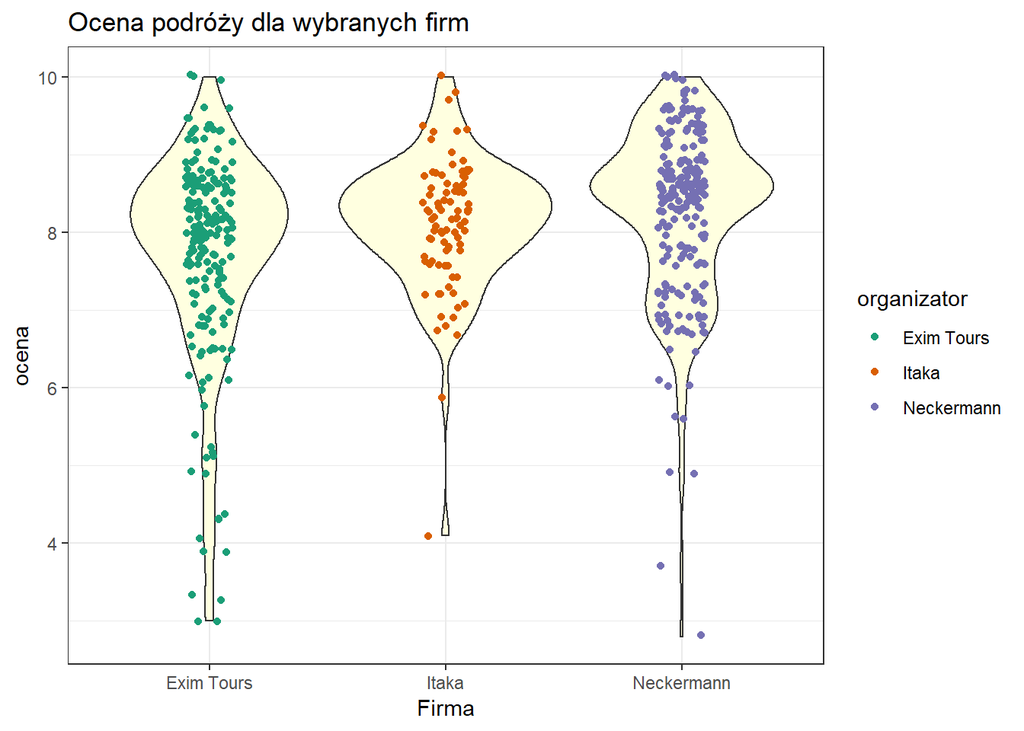

```r
#VIOLIN PLOT
ggplot(d.select2, aes(y = ocena_wycieczki, x = organizator))+
  labs(title = 'Ocena podróży dla wybranych firm', x = 'Firma', y = 'ocena')+
  geom_violin(fill = 'light yellow')+
  geom_jitter(aes(col = organizator), na.rm = TRUE, shape = 16, position = position_jitter(0.1))+
  scale_color_brewer(palette="Dark2")
```

Dalej rozpatrzmy średnie ceny każdego z organizatorów i przeanalizujmy średni koszt podróży dla różnych typów wyżywienia.

```r
#Lollipop PLOT - srednie ceny przewoznikow i typow wyzywienia

d.select3 <- aggregate(d[,12], list(d$organizator), mean)
d.select4 <- aggregate(d[,12], list(d$wyzywienie), mean)
colnames(d.select3) <- c('organizator', 'srednia_cena')
colnames(d.select4) <- c('wyzywienie', 'srednia_cena_wyzywienia')
d.select3
```

```
##      organizator srednia_cena
## 1           Atur     1583.000
## 2   Ecco Holiday     2590.000
## 3     Exim Tours     2106.303
## 4          Itaka     2997.018
## 5   Itaka & Gala     3852.889
## 6     Neckermann     3928.088
## 7  Prima Holiday     2006.625
## 8        Rainbow     2847.598
## 9         Regent     2395.000
## 10         Wezyr     1843.745
```

```r
d.select4
```

```
##                  wyzywienie srednia_cena_wyzywienia
## 1             All Inclusive                2826.317
## 2         All Inclusive 24h                3279.000
## 3        All Inclusive soft                2659.000
## 4       All Inclusive ultra                2809.000
## 5            bez wyżywienia                2133.477
## 6                 śniadania                2834.153
## 7 śniadania i obiadokolacje                2967.640
## 8              trzy posiłki                2130.000
## 9          Wszystko w cenie                4168.782
```

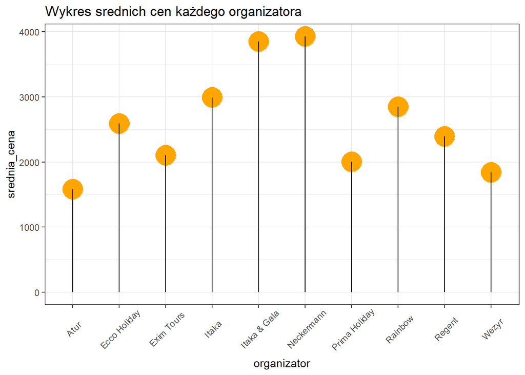

```r
theme_set(theme_bw())

ggplot(d.select3, aes(x = organizator, y = srednia_cena))+
  geom_point(size=9, col = 'orange') +
  geom_segment(aes(x=organizator,
                   xend=organizator,
                   y=0,
                   yend=srednia_cena)) +
  labs(title="Wykres srednich cen każdego organizatora") +
  theme(axis.text.x = element_text(angle=45, vjust=0.6))
```

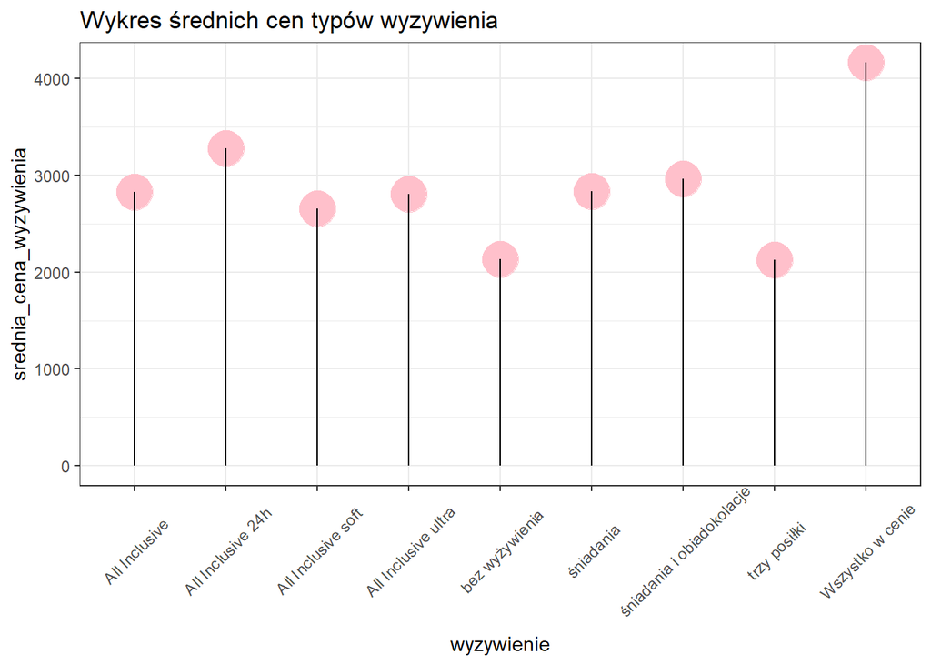

```r
ggplot(d.select4, aes(x = wyzywienie, y = srednia_cena_wyzywienia))+
  geom_point(size=9, col = 'pink') +
  geom_segment(aes(x=wyzywienie,
                   xend=wyzywienie,
                   y=0,
                   yend=srednia_cena_wyzywienia)) +
  labs(title="Wykres średnich cen typów wyzywienia") +
  theme(axis.text.x = element_text(angle=45, vjust=0.6))
```

Na **czwartym** wykresie w kształcie lizaka stworzonego przy pomocy połączenia `geom_point` i `geom_segment` widzimy poziom średnich cen dla każdej firmy. Najtanszą firmą okazał się *Atur* ze średnią ceną 1583 zł, lecz ten organizator reprezentuje jedynie 0,2% wszystkich podróży. Najdroższymi organizatorami są *Neckermann* - 3928 zł oraz *Itaka & Gala* - 3852 zł za osobę. W średnim przedziale cenowym zawarte są *Rainbow*, *Regent*, *Itaka* oraz wcześniej wiele razy wspominany *Exim Tours*.

Na podstawie analizy wyżej optymalnym jest wybór oferty *trzy posiłki*’.

Następny, **szósty** wykres przedstawia tabliczkę `10x10`, którą podzielono na kwadraty w zależności od liczby obserwacji dla różnych typów wyżywienia. Wykonany został przy pomocy `geom_tile`. Tabliczka nie zawiera *All Inclusive ultra*, *All Inclusive 24h* i *All Inclusive soft* ze względu na małą liczbę obserwacji. Najwięcej ofert zawiera w sobie tylko *śniadania* oraz *śniadania i obiadokolacje*, najmniej - trzy posiłki.

```r
#WAFFLE CHART
var <- d$wyzywienie

#robie siatke 10x10
nrows <- 10
d.select5 <- expand.grid(y = 1:nrows, x = 1:nrows)
categ_table <- round(table(var) * ((nrows*nrows)/(length(var))))
print('Liczba kwadratów dla każdego typu wyżywienia:')
```

```
## [1] "Liczba kwadratów dla każdego typu wyżywienia:"
```

```r
categ_table
```

```
## var
##             All Inclusive         All Inclusive 24h
##                        16                         0
##        All Inclusive soft       All Inclusive ultra
##                         0                         0
##            bez wyżywienia                 śniadania
##                        15                        35
## śniadania i obiadokolacje              trzy posiłki
##                        27                         1
##          Wszystko w cenie
##                         6
```

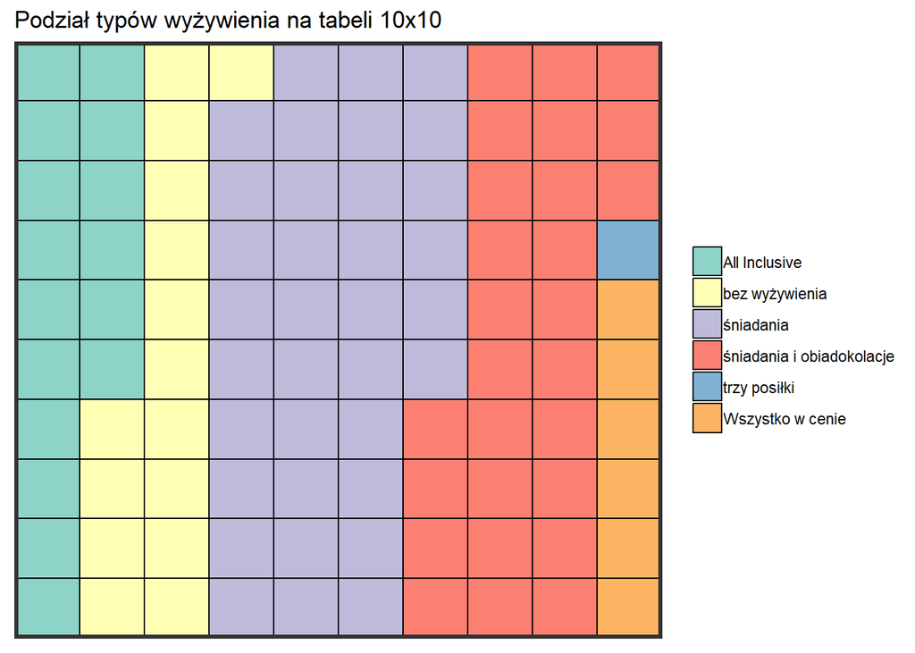

```r
d.select5$category <- factor(rep(names(categ_table), categ_table))

#Plot
ggplot(d.select5, aes(x = x, y = y, fill = category)) +
  geom_tile(color = "black", size = 0.5) +
  scale_x_continuous(expand = c(0, 0)) +
  scale_y_continuous(expand = c(0, 0), trans = 'reverse') +
  scale_fill_brewer(palette = "Set3") +
  labs(title="Podział typów wyżywienia na tabeli 10x10") +
  theme(panel.border = element_rect(size = 2),
        plot.title = element_text(size = rel(1.2)),
        axis.text = element_blank(),
        axis.title = element_blank(),
        axis.ticks = element_blank(),
        legend.title = element_blank(),
        legend.position = "right")
```

```r
#Soft, ultra, 24h za malo, zeby tutaj sie wyswietlilo
```

Kolejnym obiektem analizy będzie podział na **klastry**. Przy pomocy funkcji `prcomp` z pakietu `ggfortify`, która oblicza elementy *Analizy Głównych Składowych* - (Principal Components Analysis). Jest to jedna ze statystycznych metod analizy czynnikowej, która służy odnajdywaniu struktur w zbiorze zmiennych losowych. PCA może być oparta albo na macierzy korelacji, albo macierzy kowariancji utworzonej ze zbioru wejściowego. W tym przypadku na wykresie są pokazane odchylenia od średniej ceny dla trzech firm. Klastry trzech biur podróży zbudowane na podstawie *ceny_za_osobe* i *oceny_wycieczki*. Nie można wyraźnie wyodrębnić klastrów, ponieważ wszystkie trzy wyraźnie na siebie nachodzą. Bardziej po prawej znajduje się klaster firmy *Neckermann*, po lewej *Exim Tours*. Na środku *Ecco Holiday*. Z takiego podziału wynika, że pierwsza firma jest droższa i lepiej oceniana niż dwie pozostałe.

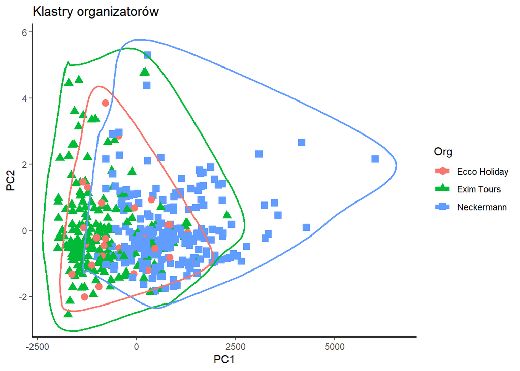

```r
library(ggfortify) #Unified plotting tools for statistics commonly used, such as GLM, time series, PCA families, clustering and survival analysis. - dokumentaja
theme_set(theme_classic())

df <- na.omit(d[c('organizator', 'cena_za_osobe', 'ocena_wycieczki')])

df1 <- df[df$organizator %in% c('Exim Tours', 'Neckermann', 'Ecco Holiday'),]

df2 <- df1[c(2,3)]

pca_mod <- prcomp(df2)


#principal components - Analiza głównych składowych - chmura N punktów w przestrzeni K-wymiarowej

  # Data frame - principal components
df_pc <- data.frame(pca_mod$x, Org=df1$organizator)  #dataframe dla principal components
df_pc_ex <- df_pc[df_pc$Org == "Exim Tours", ]  #df dla Exim Tours
df_pc_ne <- df_pc[df_pc$Org == "Neckermann", ]  #df dla Neckermann
df_pc_ec <- df_pc[df_pc$Org == "Ecco Holiday", ]  #df dla Ecco Holiday

#Plot
ggplot(df_pc, aes(PC1, PC2, col=Org)) +
  geom_point(aes(shape=Org), size=3) +
  labs(title="Klastry organizatorów") +
  coord_cartesian(xlim = 1.1 * c(min(df_pc$PC1), max(df_pc$PC1)),
                  ylim = 1.1 * c(min(df_pc$PC2), max(df_pc$PC2))) +
  geom_encircle(data = df_pc_ex, aes(x=PC1, y=PC2), size = 2) +
  geom_encircle(data = df_pc_ne, aes(x=PC1, y=PC2), size = 2) +
  geom_encircle(data = df_pc_ec, aes(x=PC1, y=PC2), size = 2)
```

Ostatnim elementem analizy będzie mapa Hiszpanii zawierająca punkty pokazujące lokalizacje, do których można pojechać zgodnie z pobranym zbiorem danych. Kolorem pokazano podział na regiony. Lokalizacje z Wysp Kanaryjskich nie zostały pokazane ze względu na odległość od lądowej części Hiszpanii. *Teneryfa* również została błędnie zlokalizowana. Naprawić to można zmieniając w `filter(lon >= -10, lon <= 10, lat >= 20)` parametry na *-30*, *30* i *0* odpowiednio, jednak dla większej czytelności wykresu zostawiłem tylko lądową część Hiszpanii z pobliskimi wyspami. *Wycieczki objazdowe* nie posiadają jednego punktu na mapie.

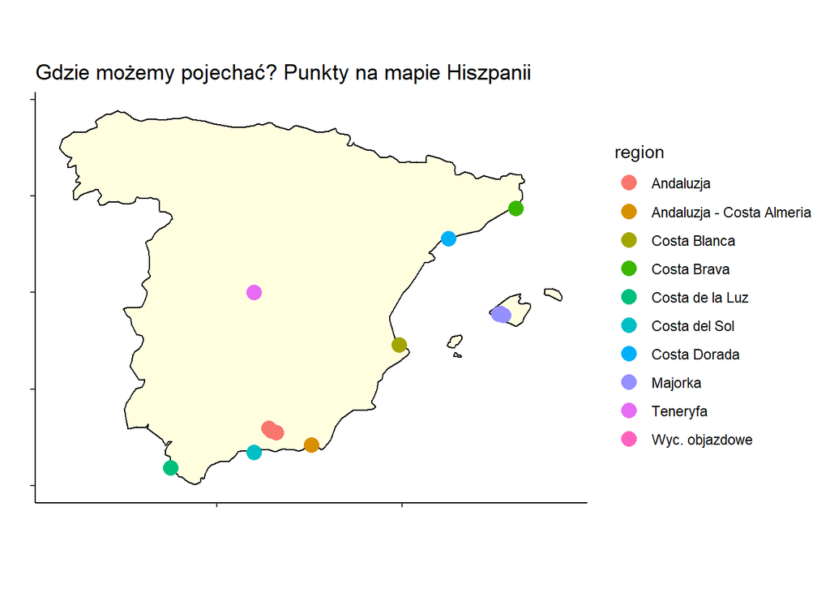

```r
library(ggmap)
spain_map <- map_data('world') %>% filter(region == "Spain")
#unikalne miejscowości
miejsca <- d %>% distinct(region, miejscowosc)

#szukam ich współrzędnych
miejsca <- miejsca %>%
  mutate(location = paste0(.$miejscowosc, ", ", .$region, ", Spain")) %>%
  mutate_geocode(location, source = "dsk", messaging = FALSE) %>%
  #ograniczam wyniki do znalezionych mniej więcej w obszarze Hiszpanii
  filter(lon >= -10, lon <= 10, lat >= 20) %>%
  #i tych, które mają jakieś dane w ogóle
  na.omit()

ggplot() +
  geom_polygon(data = spain_map, aes(long, lat, group=group),
               fill = "lightyellow", color = "black") +
  geom_point(data = miejsca, aes(lon, lat, color = region), size = 4) +
  coord_quickmap() +
  theme(axis.text.x = element_blank(), axis.text.y = element_blank()) +
  labs(title = "Gdzie możemy pojechać? Punkty na mapie Hiszpanii", x = "", y = "")
```

### Podsumowanie

Dany projekt zawiera szczegółową analizę zbioru danych opisującego wycieczki do Hiszpanii. Zostały wykorzystane takie pakiety jak `ggplot`, `lattice`, `graphics`, `rpart` itd. Wewnątrz projektu przeanalizowano różne cechy podróży, które są niezbędne dla dobrego wyboru firmy turystycznej. Na podstawie niniejszej analizy można wywnioskować, że najlepszym organizatorem wycieczek dla **niższego** segmentu cenowego jest *Exim Tours*, a dla **wyższego** - *Neckermann*. O wyborze wycieczki decydują przeróżne charakterystyki takie jak cena, oceny podróżników, lokalizacja czy typ wyżywienia. Dla zbioru pobranego w innym dniu opisy mogą stracić swoją aktualność z powodu zmian w ofertach na stronie *Wakacje.pl*.